# Practical Machine Learning-Project

### Random Forest

```r
#Random Forest
set.seed(12345)
Model_RandomForest <- randomForest(classe ~ ., data=Proj_Training)
prediction_Model_RandomForest <- predict(Model_RandomForest,  Proj_Testing, type = "class")
cmrf <- confusionMatrix(prediction_Model_RandomForest, Proj_Testing$classe)
cmrf
```

```
## Confusion Matrix and Statistics
##
##           Reference
## Prediction    A    B    C    D    E
##          A 2231    2    0    0    0
##          B    1 1516    1    0    0
##          C    0    0 1366    3    0
##          D    0    0    1 1282    0
##          E    0    0    0    1 1442
##
## Overall Statistics
##
##                Accuracy : 0.9989
##                  95% CI : (0.9978, 0.9995)
##     No Information Rate : 0.2845
##     P-Value [Acc > NIR] : < 2.2e-16
##
##                   Kappa : 0.9985
##  Mcnemar's Test P-Value : NA
##
## Statistics by Class:
##
##                      Class: A Class: B Class: C Class: D Class: E
## Sensitivity            0.9996   0.9987   0.9985   0.9969   1.0000
## Specificity            0.9996   0.9997   0.9995   0.9998   0.9998
## Pos Pred Value         0.9991   0.9987   0.9978   0.9992   0.9993
## Neg Pred Value         0.9998   0.9997   0.9997   0.9994   1.0000
## Prevalence             0.2845   0.1935   0.1744   0.1639   0.1838
## Detection Rate         0.2843   0.1932   0.1741   0.1634   0.1838
## Detection Prevalence   0.2846   0.1935   0.1745   0.1635   0.1839
## Balanced Accuracy      0.9996   0.9992   0.9990   0.9984   0.9999
```

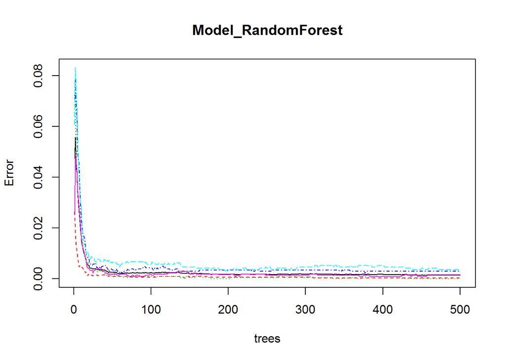

```r
plot(Model_RandomForest)
```

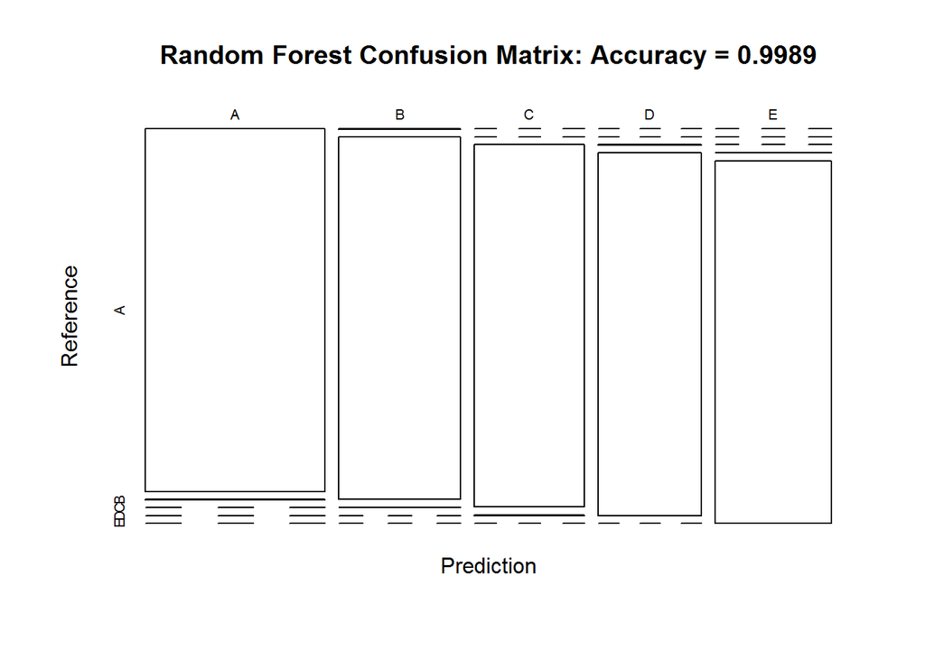

```r
plot(cmrf$table, col = cmtree$byClass, main = paste("Random Forest Confusion Matrix: Accuracy =", round(cmrf$overall['Accuracy'], 4)))
```

## Predicting on Testing data

Random Forests gave an Accuracy in the Proj_ Testing dataset of 99.89%, which was more accurate that what I got from the Decision Trees. The expected out-of-sample error is 100-99.89 = 0.11%.

```r
prediction_Testing <- predict(Model_RandomForest, testing, type = "class")
prediction_Testing
```

[output not shown]

### Decision Tree with Cross Validation

In practice, k=5 or k=10 when doing k-fold cross validation. Here we consider 5-fold cross validation (default setting in trainControl function is 10) when implementing the algorithm to save a little computing time. Since data transformations may be less important in non-linear models like classification trees, we do not transform any variables.

```r
control <- trainControl(method = "cv", number = 5)
fit_rpart <- train(classe ~ ., data = Proj_Training, method = "rpart",
                   trControl = control)
print(fit_rpart, digits = 4)
```

```
## CART
##
## 11776 samples
##    57 predictor
##     5 classes: 'A', 'B', 'C', 'D', 'E'
##
## No pre-processing
## Resampling: Cross-Validated (5 fold)
## Summary of sample sizes: 9421, 9420, 9421, 9420, 9422
## Resampling results across tuning parameters:
##
##   cp       Accuracy  Kappa
##   0.04485  0.4900    0.33899
##   0.04623  0.4036    0.19706
##   0.11450  0.3315    0.07207
##
## Accuracy was used to select the optimal model using  the largest value.
## The final value used for the model was cp = 0.04485.
```

[figure not shown]

```r
fancyRpartPlot(fit_rpart$finalModel)
```

```r
# predict outcomes using validation set
predict_rpart <- predict(fit_rpart, Proj_Testing)
# Show prediction result
conf_rpart <- confusionMatrix(Proj_Testing$classe, predict_rpart)
conf_rpart
```

```
## Confusion Matrix and Statistics
##
##           Reference
## Prediction    A    B    C    D    E
##          A 1863    0  361    0    8
##          B  787    0  731    0    0
##          C  253    0 1115    0    0
##          D  491    0  795    0    0
##          E  121    0  661    0  660
##
## Overall Statistics
##
##                Accuracy : 0.4637
##                  95% CI : (0.4526, 0.4748)
##     No Information Rate : 0.4669
##     P-Value [Acc > NIR] : 0.718
##
##                   Kappa : 0.3084
##  Mcnemar's Test P-Value : NA
##
## Statistics by Class:
##
##                      Class: A Class: B Class: C Class: D Class: E
## Sensitivity            0.5300       NA   0.3044       NA  0.98802
## Specificity            0.9148   0.8065   0.9395   0.8361  0.89106
## Pos Pred Value         0.8347       NA   0.8151       NA  0.45770
## Neg Pred Value         0.7057       NA   0.6067       NA  0.99875
## Prevalence             0.4480   0.0000   0.4669   0.0000  0.08514
## Detection Rate         0.2374   0.0000   0.1421   0.0000  0.08412
## Detection Prevalence   0.2845   0.1935   0.1744   0.1639  0.18379
## Balanced Accuracy      0.7224       NA   0.6220       NA  0.93954
```

```r
accuracy_rpart <- conf_rpart$overall[1]
accuracy_rpart
```

```
##  Accuracy
## 0.4636758
```